# Create a custom theme for ggplot2

There are many nice themes available in `{ggplot2}` and in other packages like `{ggthemes}` or `{hrbrthemes}`. We could get a decent first chart with them but for finished products we will normally need to make some small adjustments.

However, at some stage it is worth the effort to create your own theme with the defaults you normally apply to most of the charts you create.

There are many parameters to define a theme. The basis of ggplot themes is `theme_grey`, which is ggplot default. The remaining themes are changes to that basic theme. For example, `theme_minimal` applies changes to `theme_bw` which is based on `theme_grey`. Let’s see the changes `theme_minimal` does: basically removing a lot of things with `element_blank()`.

```r
library(tidyverse)

theme_minimal
```

```
## function (base_size = 11, base_family = "", base_line_size = base_size/22,
##     base_rect_size = base_size/22)
## {
##     theme_bw(base_size = base_size, base_family = base_family,
##         base_line_size = base_line_size, base_rect_size = base_rect_size) %+replace%
##         theme(axis.ticks = element_blank(), legend.background = element_blank(),
##             legend.key = element_blank(), panel.background = element_blank(),
##             panel.border = element_blank(), strip.background = element_blank(),
##             plot.background = element_blank(), complete = TRUE)
## }
## <bytecode: 0x00000000241776e0>
## <environment: namespace:ggplot2>
```

We have the plot components (axis.ticks, legend.background, etc). They are either `element_text()` like the title, `element_rect()` like the panel background, `element_line()` like the axis lines or `element_blank()` if we want to remove them.

Let’s start with the default `theme_minimal´ and we will be introducing some elements we want for our custom theme.

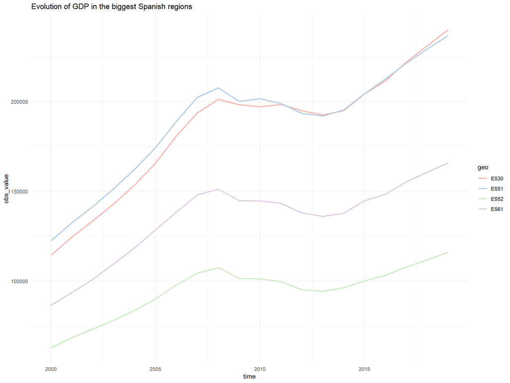

```r
df <- data.table::fread("data/gdp2v.csv") %>%
    filter(geo %in% c ("ES30", "ES51", "ES61", "ES52") &
           unit =="MIO_EUR")

p <- ggplot()+
  geom_line(data = df , aes(time,obs_value,colour=geo),size = 1)+
  scale_color_brewer(palette="Pastel1")+
  labs(title = "Evolution of GDP in the biggest Spanish regions")+
  theme_minimal(base_family = 14)

p
```

## Font and base colour

If we use a single font we can set it for all the text elements. We are going to use a google font. You can check available fonts with `font_families_google()`. We also set a base_size

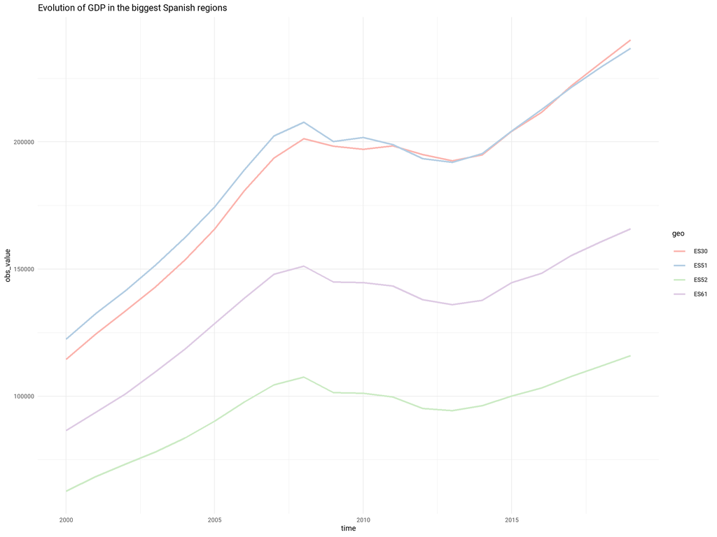

```r
library(showtext)
## Loading Google fonts (https://fonts.google.com/)
font_add_google("Roboto", "roboto")


showtext_auto()

p <- p+ theme(text = element_text(family = "roboto", size = 18))
p
```

I also define a base colour (#14509E) that will be used by several elements.

```r
base_colour <- "#14509E"
```

## Plot background

We fill the background in white and add a line with our base colour.

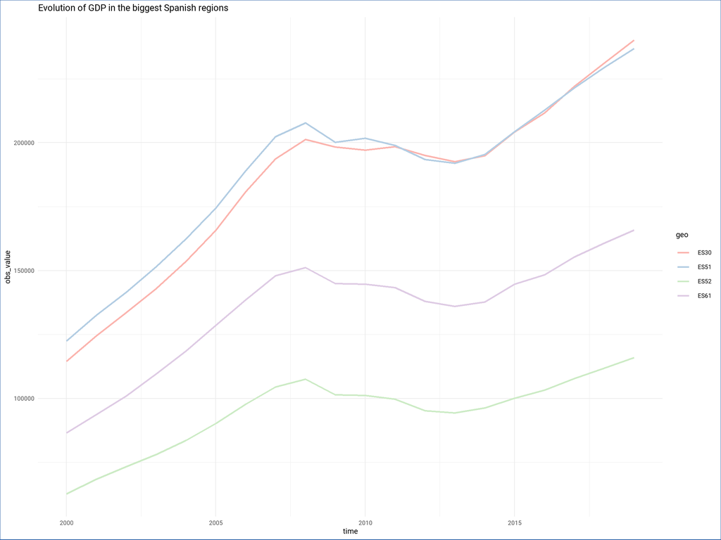

```r
p <- p +   theme(plot.background = element_rect(fill= "white",
                                       colour = base_colour))
p
```

## Panel background

We add a very light gray to the panel background and add our base colour.

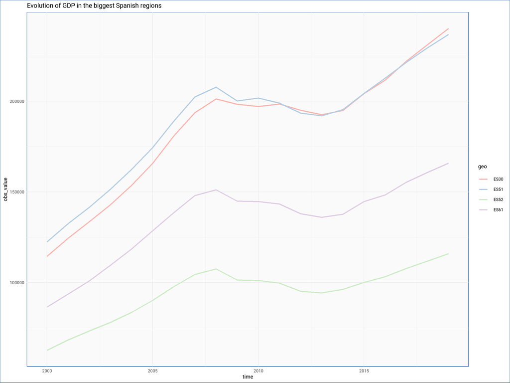

```r
p <- p + theme(panel.background = element_rect(fill= "#FAFAFA",
                                              colour = base_colour))
p
```

## Grid

We make horizontal grid lines dotted with a colour we will use in most elements. We leave the vertical major lines and minor lines with the default.

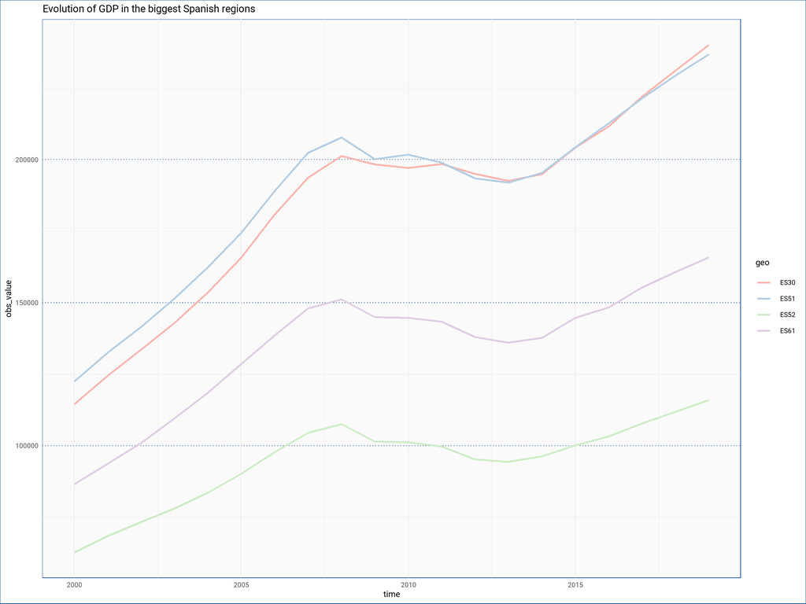

```r
p <- p+ theme(panel.grid.major.y = element_line(colour=base_colour, linetype = "dotted"))
p
```

## Axis lines

We give the base colour and make them slightly relative thicker.

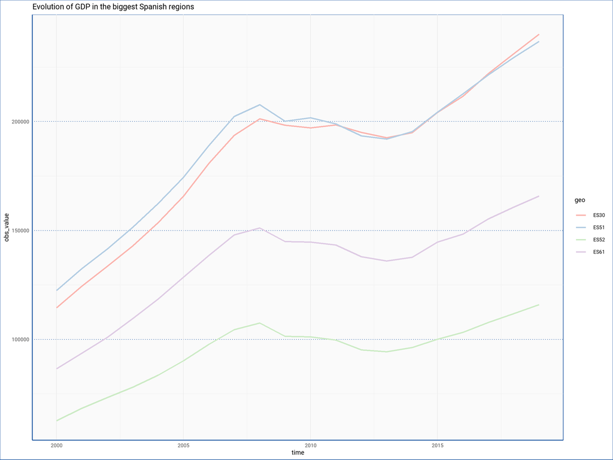

```r
p <- p + theme(axis.line.x = element_line(colour=base_colour,
                                           size =rel(1.2)),
                axis.line.y = element_line(colour= base_colour,
                                           size= rel(1.2)))
p
```

## Axis text

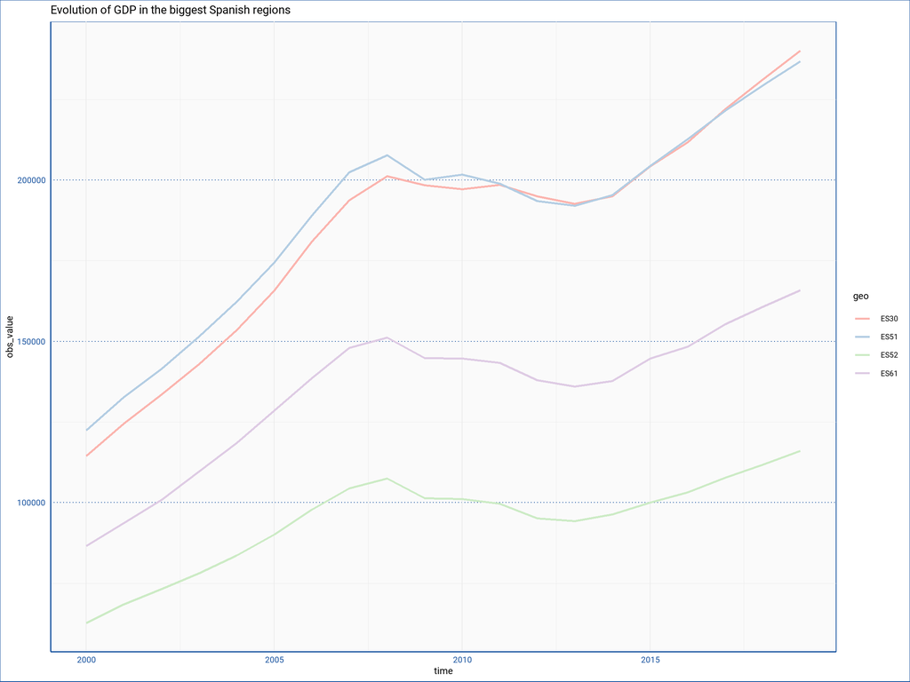

```r
p <- p + theme(axis.text.x = element_text(colour=base_colour, size =rel (1.1)),
                axis.text.y= element_text(colour= base_colour, size= rel(1.1),
                                           hjust=0))
p
```

## Axis ticks

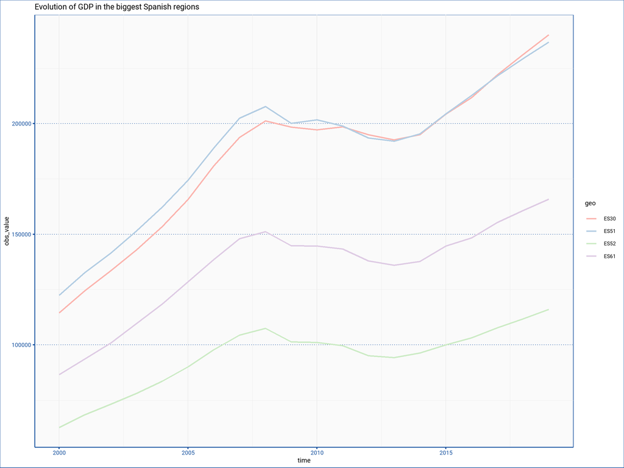

```r
p <- p + theme( axis.ticks = element_line(size =rel(1.5),
                                           colour = base_colour))

p
```

## Axis title

In most circumstances we will not use it for the x axis (time) and we change the placement in the vertical axis and made it italic

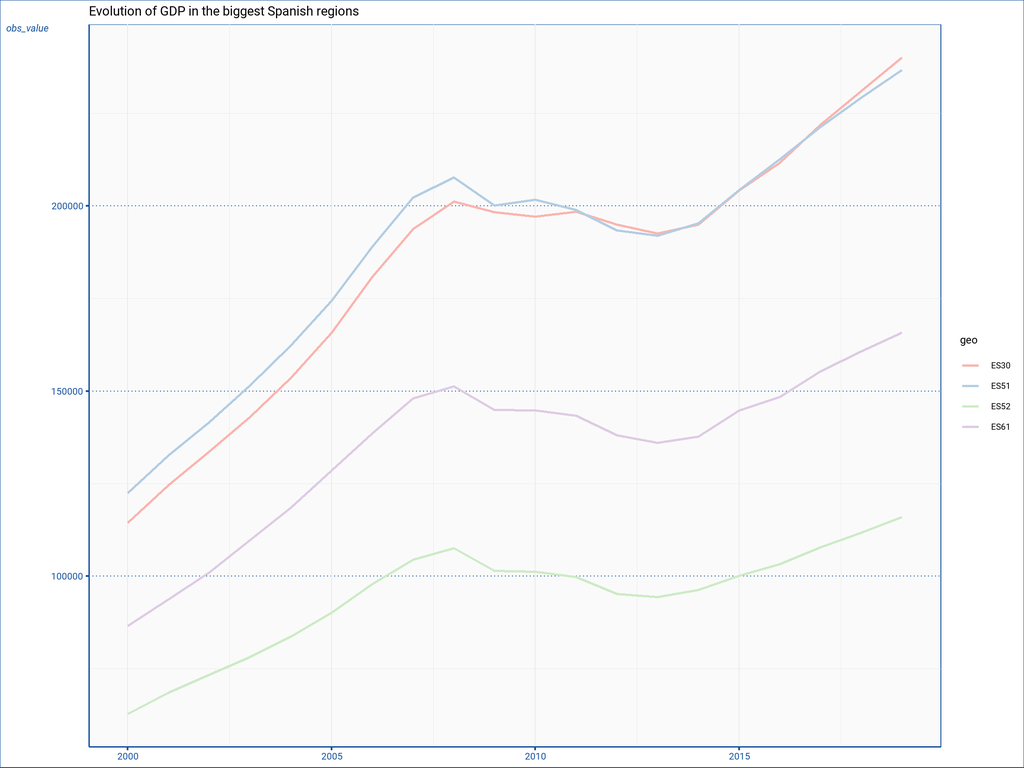

```r
p<- p + theme(axis.title.x = element_blank(),
              axis.title.y = element_text(size = rel(0.9),
                                          colour=base_colour,
                                          angle = 0,
                                          vjust = 1,
                                          face = "italic"))
p
```

## Legend

We start by placing them in the bottom

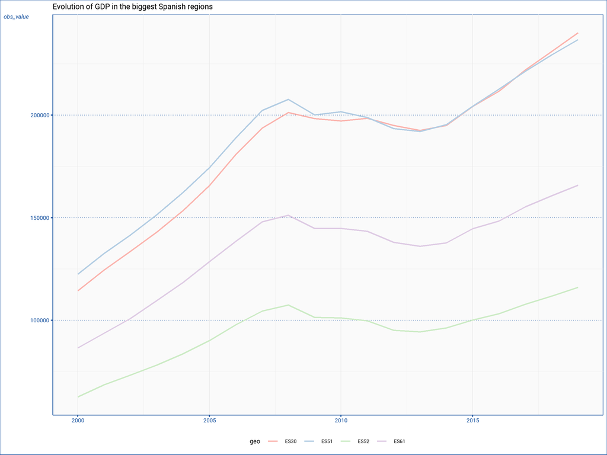

```r
p <- p + theme(legend.position = "bottom")
p
```

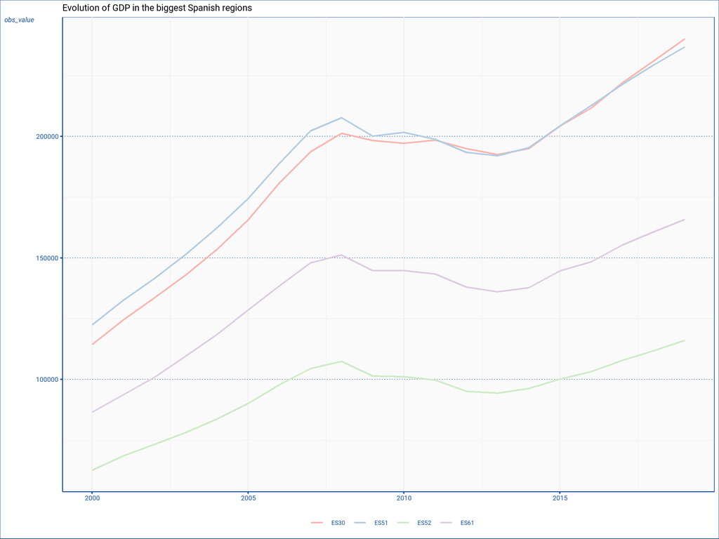

```r
p <- p + theme(legend.title = element_blank(),
           legend.key = element_rect(fill= "white",colour = NA),
           legend.background = element_rect(fill="white", colour = NA, linetype = "solid"),
           legend.text = element_text(colour= base_colour))

p
```

## Title, subtitle, caption

We make the title bold, of bigger size and change the margins.

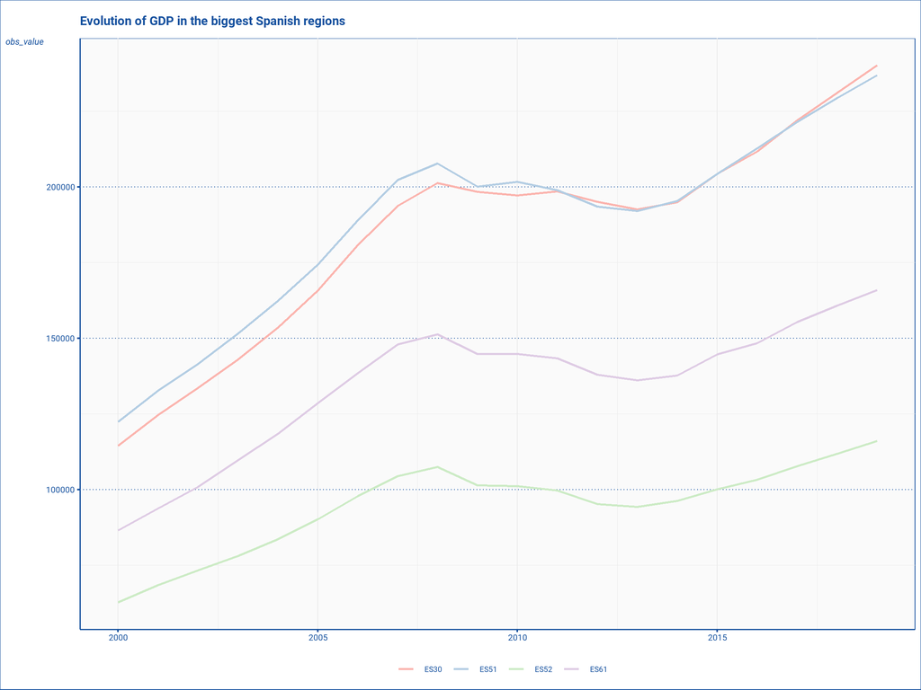

```r
p <- p + theme(plot.title = element_text(face= "bold",
                                          colour =base_colour,
                                          hjust =0,
                                          size = rel(1.3),
                                          margin = margin(10,0,10,0)))
p
```

We do something similar for the subtitle:

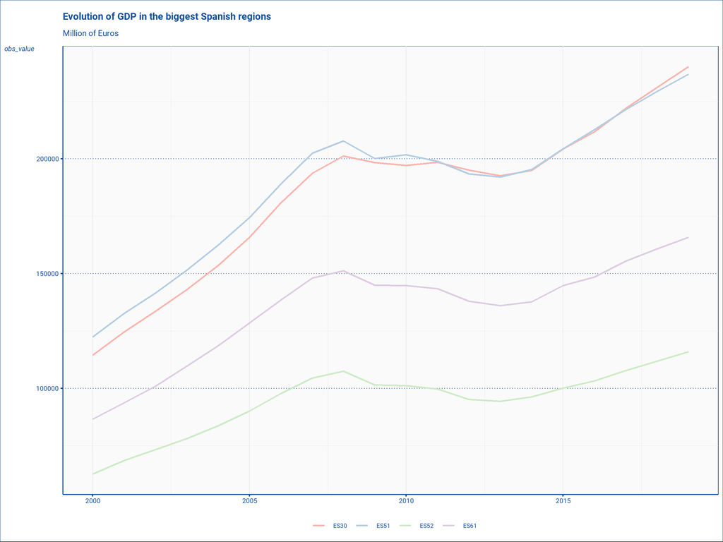

```r
p <- p + labs(subtitle = "Million of Euros")+
  theme (plot.subtitle = element_text(    colour =base_colour,
                                          hjust =0,
                                          size = rel(1.1),
                                          margin = margin(0,0,10,0)))
p
```

And the caption and tag

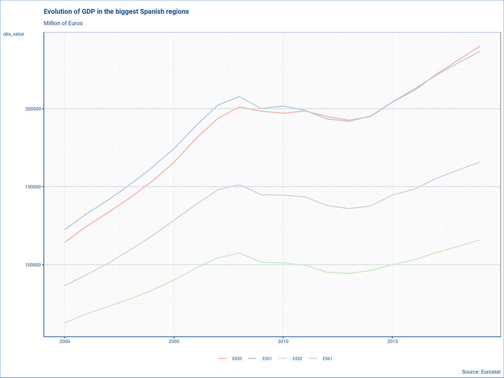

```r
p <- p + labs(caption = "Source: Eurostat")+
  theme (plot.caption = element_text(    colour =base_colour,
                                          hjust =1,
                                          size = rel(1.0)),
         plot.tag = element_text(    colour =base_colour,
                                          hjust =0,
                                          size = rel(1.0)))
p
```

## Facets

We are almost done. Let’s also fix other aspects that we may use sometimes (facets).

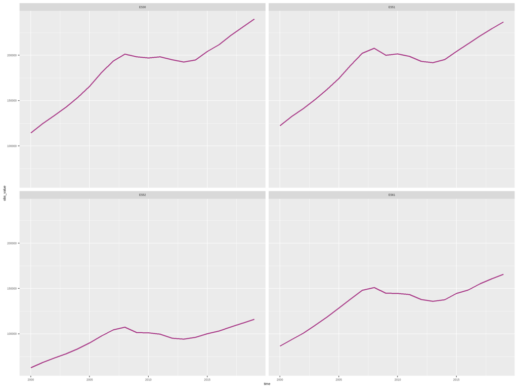

```r
p <- ggplot()+
  geom_line(data = df , aes(time,obs_value),size = 1, colour = "#AF4B91")+
 facet_wrap(~geo)
p
```

We set the strip background to our base color.

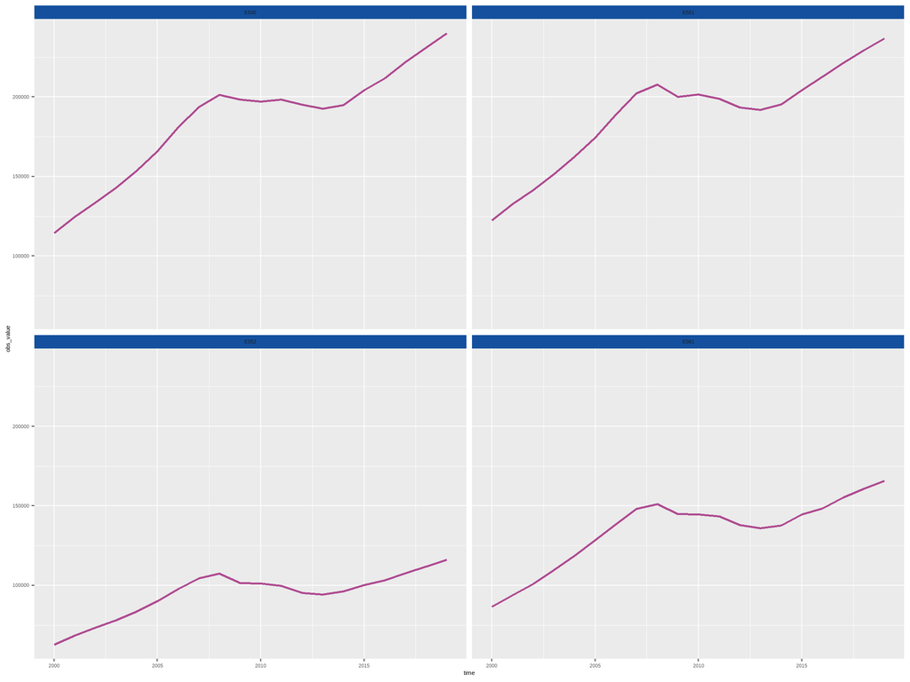

```r
p <- p + theme(strip.background = element_rect(fill = base_colour,
                                                colour = NA))
p
```

And the strip text to white, bold and give some space to the left border.

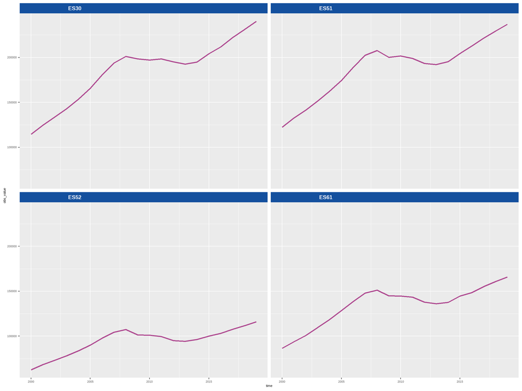

```r
p<- p + theme(strip.text = element_text(face = "bold",
                                          size = 18,
                                          hjust = 0.2,
                                          colour = "white"))
p
```

This is not relevant for this case

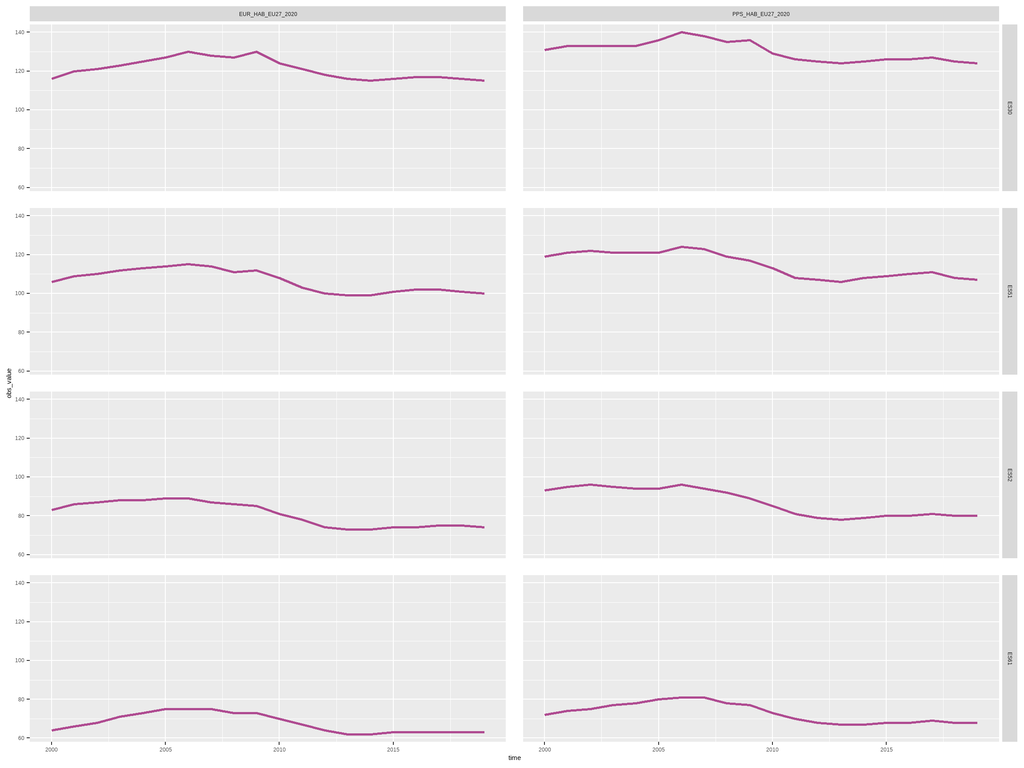

```r
df1 <- data.table::fread("data/gdp2v.csv") %>%
    filter(geo %in% c ("ES30", "ES51", "ES61", "ES52") &
           unit %in% c("EUR_HAB_EU27_2020", "PPS_HAB_EU27_2020"))

p <- ggplot()+
  geom_line(data = df1 , aes(time,obs_value),size = 1, colour = "#AF4B91")+
 facet_grid(~geo~unit)

 p <- p + theme(strip.placement = "outside",# not revevant here but for 2 dimensions
                panel.spacing = unit(1, "lines"))

 p
```

## Scales

We define now other elements outside `theme`. This is more likely to require adjustments depending on the data we use.

We can set up a number of default breaks in the axis, the type of unit to display and tweak the limits of the x access

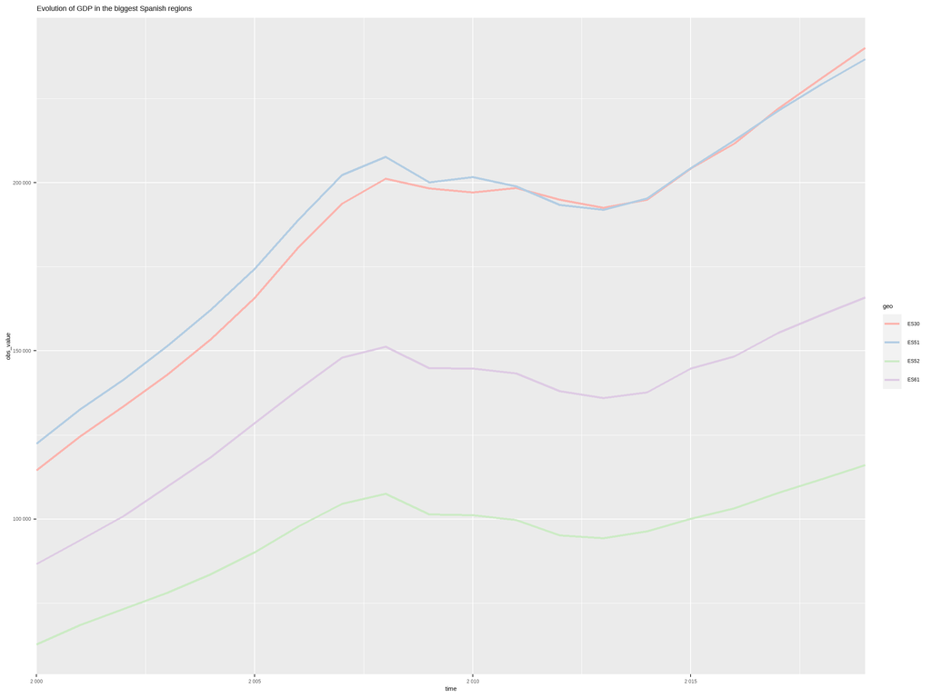

```r
library(scales)

df <- data.table::fread("data/gdp2v.csv") %>%
    filter(geo %in% c ("ES30", "ES51", "ES61", "ES52") &
           unit =="MIO_EUR")

p <- ggplot()+
  geom_line(data = df , aes(time,obs_value,colour=geo),size = 1)+
  scale_color_brewer(palette="Pastel1")+
  labs(title = "Evolution of GDP in the biggest Spanish regions")+
  scale_x_continuous(breaks = pretty_breaks(n=4), labels = label_number(accuracy = 1), expand=c(0,0))+
  scale_y_continuous(breaks = pretty_breaks(n=4), labels = label_number(accuracy = 1))

p
```

## Theme regional

Now we can create a theme that we could store as a code snippet and re-use every time we need to do a line chart.

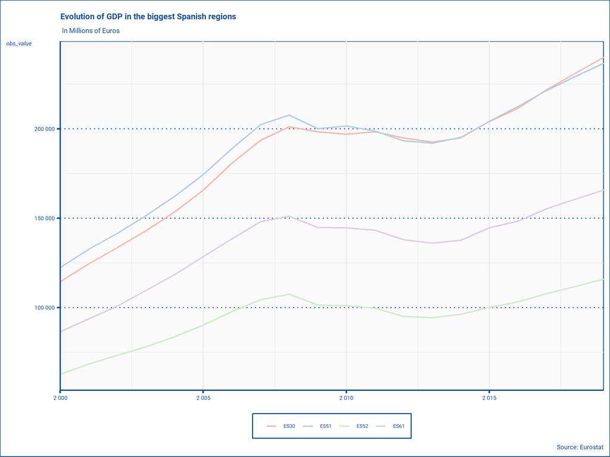

```r
base_colour <- "#14509E"
library(showtext)
library(scales)
## Loading Google fonts (https://fonts.google.com/)
font_add_google("Roboto", "roboto")


showtext_auto()

theme_regacc_line <- theme_minimal (base_size = 18,
                                    base_family = "roboto")+
                     theme(plot.background = element_rect(fill= "white",
                                       colour = base_colour),
                           panel.background = element_rect(fill= "#FAFAFA",
                                              colour = base_colour),
                           panel.grid.major.y = element_line(colour=base_colour,
                                                             linetype = "dotted"),
                           axis.line.x = element_line(colour=base_colour,
                                           size =rel(1.2)),
                           axis.line.y = element_line(colour= base_colour,
                                           size= rel(1.2)),
                           axis.text.x = element_text(colour=base_colour,
                                                      size =rel (1.1)),
                           axis.text.y= element_text(colour= base_colour,
                                                     size= rel(1.1),
                                                     hjust=0),
                           axis.ticks = element_line(size =rel(1.5),
                                                     colour = base_colour),
                           axis.title.x = element_blank(),
                           axis.title.y = element_text(size = rel(0.9),
                                          colour=base_colour,
                                          angle = 0,
                                          vjust = 1,
                                          face = "italic"),
                           legend.position = "bottom",
                           legend.title = element_blank(),
                           legend.key = element_rect(fill= "white",
                                                     colour = NA,),
                           legend.background = element_rect(fill="white",
                                                            colour = base_colour,
                                                            linetype = "solid"),
                           legend.text = element_text(colour= base_colour),
                           plot.title = element_text(face= "bold",
                                          colour =base_colour,
                                          hjust =0,
                                          size = rel(1.3),
                                          margin = margin(10,0,10,0)),
                           plot.subtitle = element_text(    colour =base_colour,
                                          hjust =0,
                                          size = rel(1.1),
                                          margin = margin(0,0,10,0)),
                           plot.caption = element_text(    colour =base_colour,
                                          hjust =1,
                                          size = rel(1.0)),
                           plot.tag = element_text(    colour =base_colour,
                                          hjust =0,
                                          size = rel(1.0)),
                           strip.background = element_rect(fill = base_colour,
                                                colour = NA),
                           strip.text = element_text(face = "bold",
                                          size = 18,
                                          hjust = 0.2,
                                          colour = "white"),
                           strip.placement = "outside",
                           panel.spacing = unit(1, "lines")
                     )

ggplot()+
  geom_line(data = df , aes(time,obs_value,colour=geo),size = 1)+
  scale_color_brewer(palette="Pastel1")+
  theme_regacc_line+
  scale_x_continuous(breaks = pretty_breaks(n=4), labels = label_number(accuracy = 1), expand=c(0,0))+
  scale_y_continuous(breaks = pretty_breaks(n=4), labels = label_number(accuracy = 1))+
  labs(title = "Evolution of GDP in the biggest Spanish regions",
       subtitle = " In Millions of Euros",
       caption = "Source: Eurostat")
```

It is easy to change the appearance of the graph. We could modify the base colour.

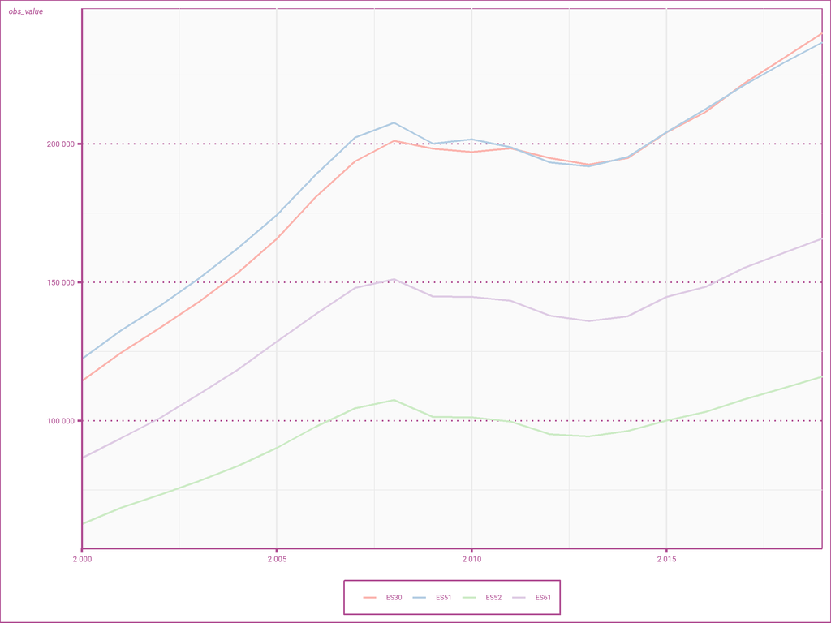

```r
base_colour <-"#AF4B91"

theme_regacc_line <- theme_minimal (base_size = 18,
                                    base_family = "roboto")+
                     theme(plot.background = element_rect(fill= "white",
                                       colour = base_colour),
                           panel.background = element_rect(fill= "#FAFAFA",
                                              colour = base_colour),
                           panel.grid.major.y = element_line(colour=base_colour,
                                                             linetype = "dotted"),
                           axis.line.x = element_line(colour=base_colour,
                                           size =rel(1.2)),
                           axis.line.y = element_line(colour= base_colour,
                                           size= rel(1.2)),
                           axis.text.x = element_text(colour=base_colour,
                                                      size =rel (1.1)),
                           axis.text.y= element_text(colour= base_colour,
                                                     size= rel(1.1),
                                                     hjust=0),
                           axis.ticks = element_line(size =rel(1.5),
                                                     colour = base_colour),
                           axis.title.x = element_blank(),
                           axis.title.y = element_text(size = rel(0.9),
                                          colour=base_colour,
                                          angle = 0,
                                          vjust = 1,
                                          face = "italic"),
                           legend.position = "bottom",
                           legend.title = element_blank(),
                           legend.key = element_rect(fill= "white",
                                                     colour = NA),
                           legend.background = element_rect(fill="white",
                                                            colour = base_colour,
                                                            linetype = "solid"),
                           legend.text = element_text(colour= base_colour),
                           plot.title = element_text(face= "bold",
                                          colour =base_colour,
                                          hjust =0,
                                          size = rel(1.3),
                                          margin = margin(10,0,10,0)),
                           plot.subtitle = element_text(    colour =base_colour,
                                          hjust =0,
                                          size = rel(1.1),
                                          margin = margin(0,0,10,0)),
                           plot.caption = element_text(    colour =base_colour,
                                          hjust =1,
                                          size = rel(1.0)),
                           plot.tag = element_text(    colour =base_colour,
                                          hjust =0,
                                          size = rel(1.0)),
                           strip.background = element_rect(fill = base_colour,
                                                colour = NA),
                           strip.text = element_text(face = "bold",
                                          size = 18,
                                          hjust = 0.2,
                                          colour = "white"),
                           strip.placement = "outside",
                           panel.spacing = unit(1, "lines")
                     )

ggplot()+
  geom_line(data = df , aes(time,obs_value,colour=geo),size = 1)+
  scale_color_brewer(palette="Pastel1")+
  theme_regacc_line+
  scale_x_continuous(breaks = pretty_breaks(n=4), labels = label_number(accuracy = 1), expand=c(0,0))+
  scale_y_continuous(breaks = pretty_breaks(n=4), labels = label_number(accuracy = 1))
```

Now it is relative easy to create another theme for other kind of plots.

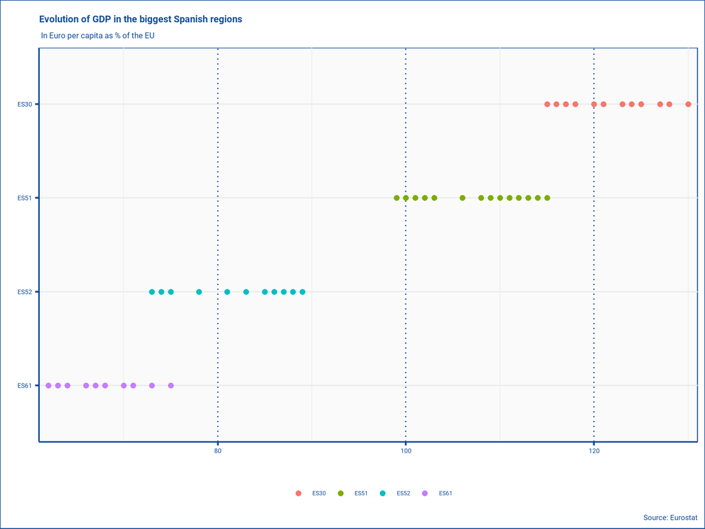

```r
base_colour <- "#14509E"

theme_regacc_dotplot <- theme_minimal (base_size = 18,
                                    base_family = "roboto")+
                     theme(plot.background = element_rect(fill= "white",
                                       colour = base_colour),
                           panel.background = element_rect(fill= "#FAFAFA",
                                              colour = base_colour),
                           panel.grid.major.x = element_line(colour=base_colour,
                                                             linetype = "dotted"),
                           axis.line.x = element_line(colour=base_colour,
                                           size =rel(1.2)),
                           axis.line.y = element_line(colour= base_colour,
                                           size= rel(1.2)),
                           axis.text.x = element_text(colour=base_colour,
                                                      size =rel (1.1)),
                           axis.text.y= element_text(colour= base_colour,
                                                     size= rel(1.1),
                                                     hjust=0),
                           axis.ticks = element_line(size =rel(1.5),
                                                     colour = base_colour),
                            axis.title.x = element_text(size = rel(0.9),
                                          colour=base_colour,
                                          angle = 0,
                                          vjust = 0.5,
                                          face = "italic"),
                           legend.position = "bottom",
                           legend.title = element_blank(),
                           legend.key = element_rect(fill= "white",
                                                     colour = NA),
                           legend.background = element_rect(fill="white",
                                                            colour = NA,
                                                            linetype = "solid"),
                           legend.text = element_text(colour= base_colour),
                           plot.title = element_text(face= "bold",
                                          colour =base_colour,
                                          hjust =0,
                                          size = rel(1.3),
                                          margin = margin(10,0,10,0)),
                           plot.subtitle = element_text(    colour =base_colour,
                                          hjust =0,
                                          size = rel(1.1),
                                          margin = margin(0,0,10,0)),
                           plot.caption = element_text(    colour =base_colour,
                                          hjust =1,
                                          size = rel(1.0)),
                           plot.tag = element_text(    colour =base_colour,
                                          hjust =0,
                                          size = rel(1.0)),
                           strip.background = element_rect(fill = base_colour,
                                                colour = NA),
                           strip.text = element_text(face = "bold",
                                          size = 18,
                                          hjust = 0.2,
                                          colour = "white"),
                           strip.placement = "outside",
                           panel.spacing = unit(1, "lines")
                     )

ggplot()+
  geom_point(data = df1 %>% filter(unit =="EUR_HAB_EU27_2020") , aes(obs_value,fct_reorder(geo,obs_value), colour = geo),size = 3)+
  theme_regacc_dotplot+
  scale_x_continuous(breaks = pretty_breaks(n=4), labels = label_number(accuracy = 1), expand = expansion(add = 1))+
  labs(title = "Evolution of GDP in the biggest Spanish regions",
       subtitle = " In Euro per capita as % of the EU",
       caption = "Source: Eurostat",
       x="",
       y = "")
```